# Cyclistic_Case_Study_Using_R

### Plotting the average ride length by weekday

```
## Defaulting to continuous.
```

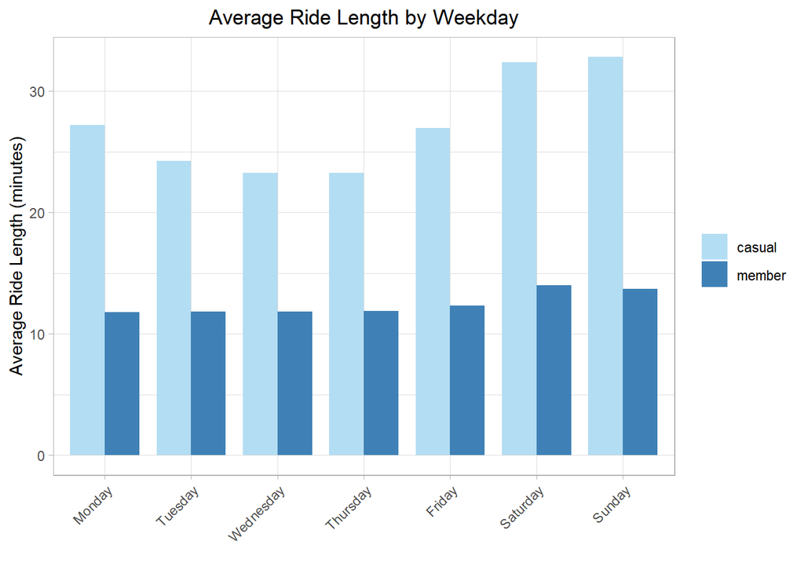

```r
avg_ride_by_weekday %>%
  ggplot(aes(x = factor(day_of_week, levels = c("Monday", "Tuesday", "Wednesday", "Thursday", "Friday", "Saturday", "Sunday")),
             y = average_ride_length, fill = member_casual)) +
  geom_col(position = "dodge", width = 0.8) +
  labs(title = "Average Ride Length by Weekday",
       y = "Average Ride Length (minutes)",
       x = "") +
  scale_fill_manual(values = c("casual" = "#B3DDF2", "member" = "#3F81B6")) +
  theme_light() +
  theme(axis.text.x = element_text(angle = 45, hjust = 1),
        plot.title = element_text(hjust = 0.5),
        legend.title = element_blank())
```

### Understanding Customer Behavior by Analyzing Bike Usage by Hour

#### Function to compute stats by hour

```r
stats_by_time_function <- function(df) {
  df %>%
    group_by(hour, member_casual) %>%
    summarize(number_of_trips = n()) %>%
    arrange(hour, member_casual)
}

stats_by_time <- stats_by_time_function(cyclistic_new_df)
```

### Plotting the results

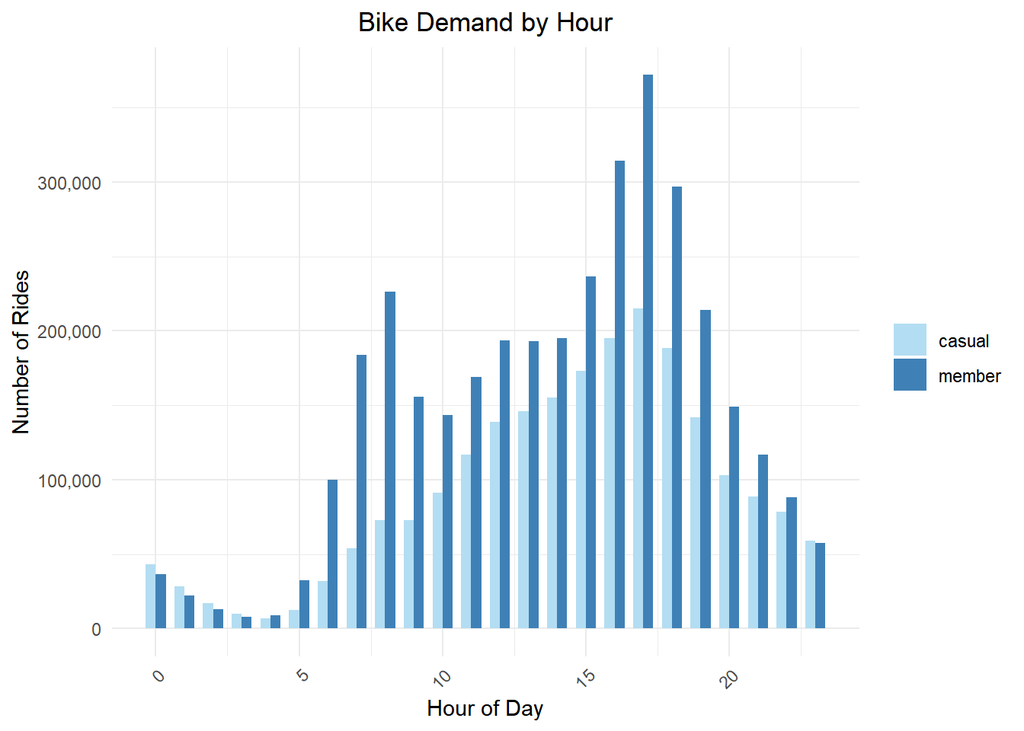

```r
stats_by_time %>%
  ggplot(aes(x = hour, y = number_of_trips, fill = member_casual)) +
  geom_col(position = "dodge", width = 0.7) +
  labs(title = "Bike Demand by Hour",
       y = "Number of Rides",
       x = "Hour of Day") +
  scale_y_continuous(labels = scales::comma) +
  scale_fill_manual(values = c("casual" = "#B3DDF2", "member" = "#3F81B6")) +
  theme_minimal() +
  theme(axis.text.x = element_text(angle = 45, hjust = 1),
        plot.title = element_text(hjust = 0.5),
        legend.title = element_blank())
```

### Understanding Customer Behavior by Analyzing Bike Usage by Day of the Week

##### Function to compute stats by weekday

```r
stats_by_weekday_function <- function(df) {
  df %>%
    group_by(day_of_week, member_casual) %>%
    summarize(number_of_rides = n(), .groups = "drop") %>%
    mutate(day_of_week = factor(day_of_week, levels = c("Monday", "Tuesday", "Wednesday", "Thursday", "Friday", "Saturday", "Sunday"))) %>%
    arrange(day_of_week)
}
```

### Function to plot stats by weekday

```r
plot_by_weekday <- function(data) {
  data %>%
    ggplot(aes(x = day_of_week, y = number_of_rides, fill = member_casual)) +
    geom_col(position = "dodge", width = 0.7) +
    labs(title = "Bike Rides by Day of the Week",
         y = "Number of Rides",
         x = "Day of the Week") +
    scale_y_continuous(labels = scales::comma) +
    scale_fill_manual(values = c("casual" = "#B3DDF2", "member" = "#3F81B6")) +
    theme_minimal() +
    theme(axis.text.x = element_text(angle = 45, hjust = 1),
          plot.title = element_text(hjust = 0.5),
          legend.title = element_blank())
}
```

### Compute stats and plot

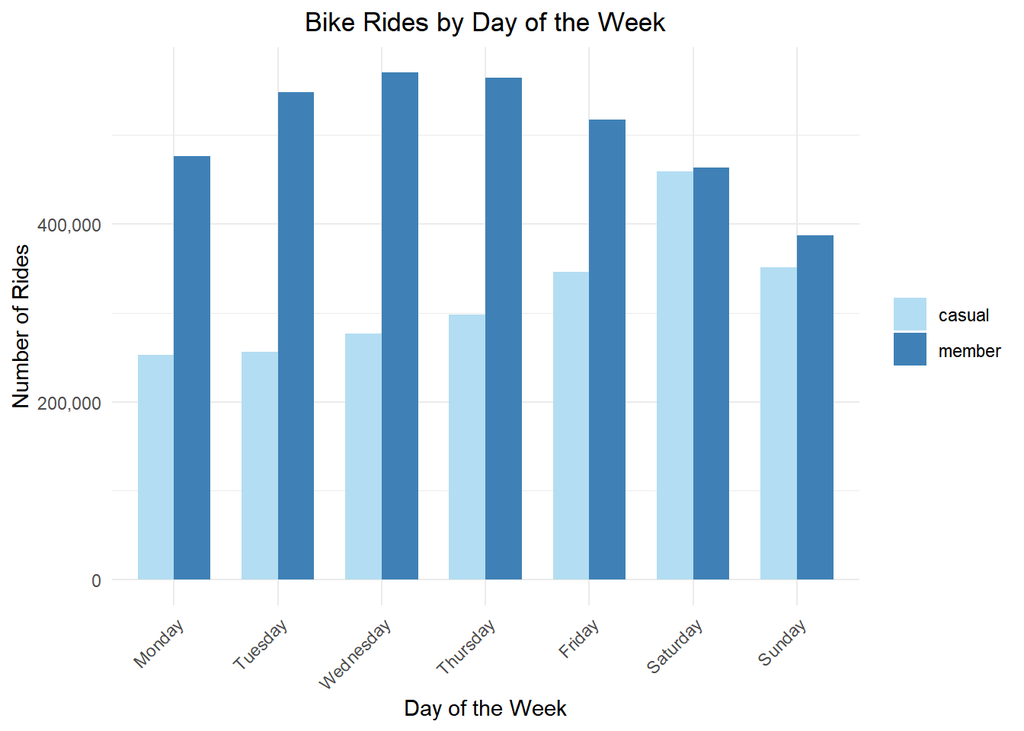

```r
weekday_data <- stats_by_weekday_function(cyclistic_new_df)
plot_by_weekday(weekday_data)
```

### Understanding Customer Behavior by Analyzing Bike Usage by Month of the Year

#### Function to compute stats by month

```r
stats_by_month_function <- function(df) {
  df %>%
    group_by(month, member_casual) %>%
    summarize(number_of_rides = n(), .groups = "drop") %>%
    arrange(match(month, month.name), member_casual)
}
```

### Compute stats

```r
stats_by_month_data <- stats_by_month_function(cyclistic_new_df)
```

### Plotting the results

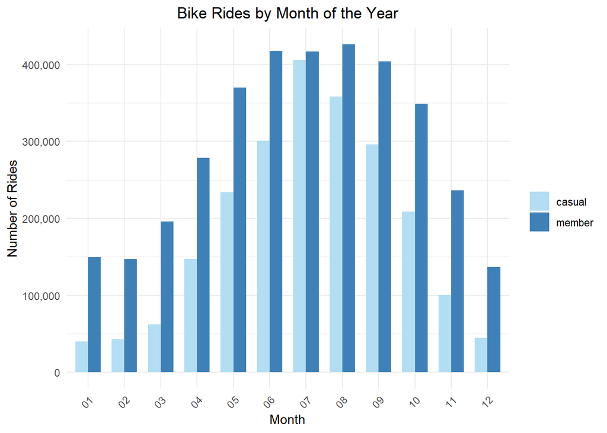

```r
stats_by_month_data %>%
  ggplot(aes(x = month, y = number_of_rides, fill = member_casual)) +
  geom_col(position = "dodge", width = 0.7) +
  labs(title = "Bike Rides by Month of the Year",
       y = "Number of Rides",
       x = "Month") +
  scale_y_continuous(labels = scales::comma) +
  scale_fill_manual(values = c("casual" = "#B3DDF2", "member" = "#3F81B6")) +
  theme_minimal() +
  theme(axis.text.x = element_text(angle = 45, hjust = 1),
        plot.title = element_text(hjust = 0.5),
        legend.title = element_blank())
```

##Key Findings for Cyclistic Bike Share Usage 🔑

### My analysis of Cyclistic’s bike share data has revealed interesting usage patterns:

- **Ride Frequency**: The bulk of the rides are dominated by members, contributing to 61.2% of the total. In comparison, casual riders are responsible for 38.8% of the rides. This skew underscores the loyalty and habitual usage patterns of members.
- **Ride Duration Disparity**: Casual riders are not in a hurry, it seems! Their rides average 27.77 minutes, a leisurely pace in contrast to the brisk 12.41 minutes that members spend on average for their trips. The shorter rides of members may hint at utilitarian trips, while casual users indulge in longer, exploratory rides.
- **Peak Usage Times**: A synchrony is observed in the usage patterns of both member and casual riders around 17:00 (5 pm). This popular window may coincide with the end of a workday, an opportune moment for a ride.
- **Weekday Analysis**: The weekdays are bustling for members, suggesting a potential alignment with work-related commutes. On the flip side, casual riders are most active during the weekends, painting a picture of recreational usage.
- **Monthly Trends**: Summer is the reigning champion for both categories of riders. June, July, and August see the highest usage. A noteworthy mention is the continued preference of members for biking even into September, possibly stretching their work-related commutes a bit more before winter sets in.

## Differences in Usage Between Annual Members and Casual Riders

### Frequency & Duration

- **Members**: Represent 61.2% of total rides with brisk, purpose-driven rides averaging 12.41 minutes.
- **Casual Riders**: Constitute 38.8% of rides, indulging in more leisurely rides, averaging 27.77 minutes.

### Peak Times & Weekday Patterns

- **Shared Peak Time**: Both groups converge in usage around 17:00 (5 pm).
- **Usage Pattern**: Members lean towards weekdays, likely for commuting. Casual riders are active on weekends, suggesting recreational intent.

### Seasonal Trends

- **Summer Surge**: Summer sees a ride surge for both categories. Members, however, persist with high usage into September.

## Recommendations for Encouraging Casual Riders to Purchase Annual Memberships

### Cost Efficiency for Regular Riders

- **Spring 2024 Pass**: A limited three-month discounted pass for spring can attract casual riders by demonstrating value over single-use fares.

### Exclusive Benefits & Perks

- **Member-Only Rewards**: By introducing exclusive perks like special bikes, discounts, or early access events for members, Cyclistic can create a compelling case for casual riders to commit to longer-term memberships.

## How can Cyclistic use digital media to influence casual riders to become members?

### Targeted Advertising

Amplify brand awareness with **targeted campaigns at high-frequency stations during peak hours (5 p.m.) and summer months**.

### Engaging Content

- **Weekend Wonders**: Collaborate with renowned influencers to spotlight Chicago’s prime locations best explored by bike.
- **Healthy Commutes**: Promote the health benefits of daily bike commuting.
- **Transformational Tales**: Share impactful stories of individuals whose lives transformed positively through regular cycling.

### Exclusive Digital Offers

Unveil time-limited membership deals targeting casual riders on emails, social media, and partner apps.

### Seasonal Campaigns

Capitalize on summer’s allure with offers such as **“Summer Special 2024” or September’s “Ride into Autumn 2024”** to captivate casual riders.

### Interactive Tools

Launch a “Savings Calculator” online, empowering casual riders to visualize potential savings with memberships.

### SEO Strategy

- **Search Intent**: Boost organic reach with an SEO campaign focusing on queries about **cycling in Chicago**.
- **Engaging Queries**: Address questions like **“Best bike spots in Chicago”** or **“Chicago bike rental costs”** to build a memorable brand presence.